# EstudoDeCaso1

Luiz Paulo Rodrigues Almeida

2023-01-17

## Unificação e limpeza dos Datasets

A análise proposta deve se basear nos dados dos últimos 12 meses de utilização das bicicletas da Cyclistic (nome fictício) empresa de aluguel de bicicletas com base na cidade de Chicago.

Os dados se encontram [nesse link](https://divvy-tripdata.s3.amazonaws.com/index.html) (dados cedidos pela empresa Motivate International Inc. sobs a essa [licença](https://www.divvybikes.com/data-license-agreement) armazenados no AWS), mas não estão em único arquivo e sim separados mês a mês, portanto, esse script tem como um dos principais objetivos a unificação e preparação desses arquivos em um único dataset.

### Instalar e carregar as bibliotecas necessárias para os procedimentos

```r
    #install.packages("tidyverse") #manipulações básicas como Rename e Mutate
    #install.packages("lubridate") #manipular datas
    #install.packages("janitor") #corrigir nomes de colunas e duplicatas
    #install.packages("scales") #corrigir escalas com notação científica
    #install.packages("knitr") #para o knit
    #install.packages("dplyr")
    library("tidyverse")
    library("lubridate")
```

```r
    library("ggplot2")
    library("janitor")
    library("scales")
    library("knitr")
    library("dplyr")
```

### Carregar os arquivos

Primeiro vamos carregar um a um, adotando a convenção “nomedaempre_infoviagens_yyyymm” para cada dataframe

```r
    getwd() #verificar se estamos no diretório correto
```

```
## [1] "D:/R/Coursera/EstudoDeCaso1"
```

```r
    #setwd() #Usar somente em caso de divergência nos diretórios
    cyclistic_infoviagens_202201 <- read.csv("202201-divvy-tripdata.csv")
    cyclistic_infoviagens_202202 <- read.csv("202202-divvy-tripdata.csv")
    cyclistic_infoviagens_202203 <- read.csv("202203-divvy-tripdata.csv")
    cyclistic_infoviagens_202204 <- read.csv("202204-divvy-tripdata.csv")
    cyclistic_infoviagens_202205 <- read.csv("202205-divvy-tripdata.csv")
    cyclistic_infoviagens_202206 <- read.csv("202206-divvy-tripdata.csv")
    cyclistic_infoviagens_202207 <- read.csv("202207-divvy-tripdata.csv")
    cyclistic_infoviagens_202208 <- read.csv("202208-divvy-tripdata.csv")
    cyclistic_infoviagens_202209 <- read.csv("202209-divvy-tripdata.csv")
    cyclistic_infoviagens_202210 <- read.csv("202210-divvy-tripdata.csv")
    cyclistic_infoviagens_202211 <- read.csv("202211-divvy-tripdata.csv")
    cyclistic_infoviagens_202212 <- read.csv("202212-divvy-tripdata.csv")
```

### Verificar se a estrutura de cada arquivo corresponde

Essa etapa é necessário pois caso haja qualquer divergência, seja no nome das colunas ou no tipo de dados, será necessário fazer ajustes nos nomes daquelas colunas que forem diferentes ou nos tipos de dados que não estiverem em conformidade para que os datasets sejam unidos em um único dataframe com todos os dados.

Como são muitos arquivos é bom realizar um comparação de dois em dois ou usar uma função, optei por usar uma função presente na biblioteca ‘janitor’.

```r
    janitor::compare_df_cols(cyclistic_infoviagens_202201,
                             cyclistic_infoviagens_202202,
                             cyclistic_infoviagens_202203,
                             cyclistic_infoviagens_202204,
                             cyclistic_infoviagens_202205,
                             cyclistic_infoviagens_202206,
                             cyclistic_infoviagens_202207,
                             cyclistic_infoviagens_202208,
                             cyclistic_infoviagens_202209,
                             cyclistic_infoviagens_202210,
                             cyclistic_infoviagens_202211,
                             cyclistic_infoviagens_202212)
```

```
##           column_name cyclistic_infoviagens_202201 cyclistic_infoviagens_202202
## 1             end_lat                      numeric                      numeric
## 2             end_lng                      numeric                      numeric
## 3      end_station_id                    character                    character
## 4    end_station_name                    character                    character
## 5            ended_at                    character                    character
## 6       member_casual                    character                    character
## 7             ride_id                    character                    character
## 8       rideable_type                    character                    character
## 9           start_lat                      numeric                      numeric
## 10          start_lng                      numeric                      numeric
## 11   start_station_id                    character                    character
## 12 start_station_name                    character                    character
## 13         started_at                    character                    character
##    cyclistic_infoviagens_202203 cyclistic_infoviagens_202204
```

[output cut: 69 more lines]

### Corrigir estrutura dos dataframes

Incrivelmente todas as colunas e tipos de dados acabaram batendo, então não há necessidade de corrigir nada em nenhum dos dataframes relativo à estrutura antes de fundir todos eles.

### Fundir os dataframes

Nessa parte iremos juntar os 12 dataframes para criar um único dataframe gigante, também vou salvar esse dataframe como um dataset grande para poupar futuros problemas com carregamento (vale notar que somente o carregamente desses 12 datasets resultou em mais de 2,42GiB de memória Ram consumida - não daria para fazer isso na versão free do R Studio Cloud por exemplo)

- Não rodar esse bloco indiscriminadamente, mesmo num pc gamer levou uns 7 minutos pra executar tudo.

```r
    cyclistic_infoviagens_2022 <- rbind(cyclistic_infoviagens_202201,
                                        cyclistic_infoviagens_202202,
                                        cyclistic_infoviagens_202203,
                                        cyclistic_infoviagens_202204,
                                        cyclistic_infoviagens_202205,
                                        cyclistic_infoviagens_202206,
                                        cyclistic_infoviagens_202207,
                                        cyclistic_infoviagens_202208,
                                        cyclistic_infoviagens_202209,
                                        cyclistic_infoviagens_202210,
                                        cyclistic_infoviagens_202211,
                                        cyclistic_infoviagens_202212)

    write.csv(cyclistic_infoviagens_2022, "cyclistic_infoviagens_2022.csv", row.names = FALSE)
```

### Verificando o novo dataset, algumas limpezas provavlemente serão necessárias.

Com a análise vai se basear nos hábitos entre usuários casuais e assinantes, é necessário verificar a coluna membro (só deve possuir dois valores), criar um coluna para calcular as durações das corridas também pode ser uma boa ideia, é possível que esses dois grupos utilizem as bicicletas por tempos diferentes.

Vamos também aproveitar para adicionar uma coluna com a duração da viagem no dataset, calculando o tempo entre o fim da viagem e o início da viagem.

Algumas colunas trambém serão excluídas já que não terão impacto na analise, as colunas de latitude e longitude.

```r
    #cyclistic_infoviagens_2022 <- read.csv("cyclistic_infoviagens_2022.csv") #apenas pra facilitar leitura

    #verificar se só tem duas categorias de membro
    unique(cyclistic_infoviagens_2022$member_casual)
```

```
## [1] "casual" "member"
```

```r
    #excluir as colunas de lat e lon
    cyclistic_infoviagens <- cyclistic_infoviagens_2022[, -c(9,10,11,12)]

    #duração da viagem
    cyclistic_infoviagens$duration <- difftime(cyclistic_infoviagens$ended_at,
                                               cyclistic_infoviagens$started_at, units="mins") #converter pra numerico?

    #Também parece ser pertinente analisar os dias da semana, então vamos criar uma nova coluna
    cyclistic_infoviagens$weekday <- weekdays(as.Date(cyclistic_infoviagens$started_at))

    str(cyclistic_infoviagens)
```

```
## 'data.frame':    5667717 obs. of  11 variables:
##  $ ride_id           : chr  "C2F7DD78E82EC875" "A6CF8980A652D272" "BD0F91DFF741C66D" "CBB80ED419105406" ...
##  $ rideable_type     : chr  "electric_bike" "electric_bike" "classic_bike" "classic_bike" ...
##  $ started_at        : chr  "2022-01-13 11:59:47" "2022-01-10 08:41:56" "2022-01-25 04:53:40" "2022-01-04 00:18:04" ...
##  $ ended_at          : chr  "2022-01-13 12:02:44" "2022-01-10 08:46:17" "2022-01-25 04:58:01" "2022-01-04 00:33:00" ...
##  $ start_station_name: chr  "Glenwood Ave & Touhy Ave" "Glenwood Ave & Touhy Ave" "Sheffield Ave & Fullerton Ave" "Clark St & Bryn Mawr Ave" ...
##  $ start_station_id  : chr  "525" "525" "TA1306000016" "KA1504000151" ...
##  $ end_station_name  : chr  "Clark St & Touhy Ave" "Clark St & Touhy Ave" "Greenview Ave & Fullerton Ave" "Paulina St & Montrose Ave" ...
##  $ end_station_id    : chr  "RP-007" "RP-007" "TA1307000001" "TA1309000021" ...
##  $ member_casual     : chr  "casual" "casual" "member" "casual" ...
##  $ duration          : 'difftime' num  2.95 4.35 4.35 14.9333333333333 ...
##   ..- attr(*, "units")= chr "mins"
##  $ weekday           : chr  "quinta-feira" "segunda-feira" "terça-feira" "terça-feira" ...
```

### Verificando NAs, NaN e nulos

Existe um total de 5.667.717 observações no banco de dados, mas eliminaremos da análise NAs e valores nulos porque eles podem influenciar muito, negativamente, na análise dependendo das colunas que tiverem esses valores. Exemplo: local de partida e local de chegada são essenciais para a análise

Update: adicionei as_tibble nas consultas para não gerar um relatório imenso ao fazer o knit

```r
    #Verificar colunas de inicio de viagem
    as_tibble(cyclistic_infoviagens) %>%
                            filter((is.na(start_station_name) | start_station_name =="" | start_station_name ==" ")&
                                     is.na(start_station_id) | (start_station_id =="" | start_station_id ==" "))
```

```
## # A tibble: 833,064 × 11
##    ride_id       ridea…¹ start…² ended…³ start…⁴ start…⁵ end_s…⁶ end_s…⁷ membe…⁸
##    <chr>         <chr>   <chr>   <chr>   <chr>   <chr>   <chr>   <chr>   <chr>
##  1 857B71104B43… electr… 2022-0… 2022-0… ""      ""      Lockwo… 312     casual
##  2 565EEF32A9B6… electr… 2022-0… 2022-0… ""      ""      Ashlan… 13319   member
##  3 C1C191026014… electr… 2022-0… 2022-0… ""      ""      Ashlan… 13319   member
##  4 A3CE92127200… electr… 2022-0… 2022-0… ""      ""      Southp… TA1309… member
##  5 A285AF99096A… electr… 2022-0… 2022-0… ""      ""      Southp… TA1309… member
##  6 80F29B80E0DF… electr… 2022-0… 2022-0… ""      ""      Wallac… TA1308… member
##  7 5D1029D15EA4… electr… 2022-0… 2022-0… ""      ""      Woodla… KA1503… member
##  8 14AAFBC4ACE6… electr… 2022-0… 2022-0… ""      ""      Damen … 20.0    member
##  9 F8F5A55A2318… electr… 2022-0… 2022-0… ""      ""      Damen … 20.0    member
## 10 09BBB0D56ADE… electr… 2022-0… 2022-0… ""      ""      Kilpat… 358     casual
## # … with 833,054 more rows, 2 more variables: duration <drtn>, weekday <chr>,
## #   and abbreviated variable names ¹rideable_type, ²started_at, ³ended_at,
## #   ⁴start_station_name, ⁵start_station_id, ⁶end_station_name, ⁷end_station_id,
## #   ⁸member_casual
```

```r
    #Verificar colunas de fim de viagem
    as_tibble(cyclistic_infoviagens) %>%
                            filter((is.na(end_station_name) | end_station_name =="" | end_station_name ==" ")&
                                     is.na(end_station_id) | (end_station_id =="" | end_station_id ==" "))
```

```
## # A tibble: 892,742 × 11
##    ride_id       ridea…¹ start…² ended…³ start…⁴ start…⁵ end_s…⁶ end_s…⁷ membe…⁸
##    <chr>         <chr>   <chr>   <chr>   <chr>   <chr>   <chr>   <chr>   <chr>
##  1 88276B47FFBB… electr… 2022-0… 2022-0… Larrab… TA1306… ""      ""      member
##  2 1B66EC28DD61… electr… 2022-0… 2022-0… Centra… 369     ""      ""      member
##  3 20994C14E560… electr… 2022-0… 2022-0… Seeley… 13144   ""      ""      member
##  4 3C647408C8ED… electr… 2022-0… 2022-0… Spauld… 15654   ""      ""      casual
##  5 A1ED4CB525BE… electr… 2022-0… 2022-0… Kedzie… KA1504… ""      ""      casual
##  6 59D9EB490354… electr… 2022-0… 2022-0… Milwau… 13242   ""      ""      member
##  7 B3F4631D03DC… electr… 2022-0… 2022-0… Clinto… WL-008  ""      ""      member
##  8 B72BADA5F540… electr… 2022-0… 2022-0… Damen … 13288   ""      ""      member
##  9 519F97D3506A… electr… 2022-0… 2022-0… Wentwo… 15445   ""      ""      casual
## 10 CAEFD2DD9973… electr… 2022-0… 2022-0… Kimbal… KA1504… ""      ""      member
## # … with 892,732 more rows, 2 more variables: duration <drtn>, weekday <chr>,
## #   and abbreviated variable names ¹rideable_type, ²started_at, ³ended_at,
## #   ⁴start_station_name, ⁵start_station_id, ⁶end_station_name, ⁷end_station_id,
## #   ⁸member_casual
```

```r
    #Verificar colunas de início e fim de viagem simultaneamente
    as_tibble(cyclistic_infoviagens) %>%
                            filter(((is.na(end_station_name) | end_station_name =="" | end_station_name ==" ") &
                                    (is.na(end_station_id) | end_station_id =="" | end_station_id ==" "))
                                    |
                                  ((is.na(start_station_name)| start_station_name =="" |start_station_name ==" ") &
                                    (is.na(start_station_id) | start_station_id =="" | start_station_id ==" ")))
```

```
## # A tibble: 1,298,357 × 11
##    ride_id       ridea…¹ start…² ended…³ start…⁴ start…⁵ end_s…⁶ end_s…⁷ membe…⁸
##    <chr>         <chr>   <chr>   <chr>   <chr>   <chr>   <chr>   <chr>   <chr>
##  1 857B71104B43… electr… 2022-0… 2022-0… ""      ""      "Lockw… "312"   casual
##  2 88276B47FFBB… electr… 2022-0… 2022-0… "Larra… "TA130… ""      ""      member
##  3 1B66EC28DD61… electr… 2022-0… 2022-0… "Centr… "369"   ""      ""      member
##  4 565EEF32A9B6… electr… 2022-0… 2022-0… ""      ""      "Ashla… "13319" member
##  5 C1C191026014… electr… 2022-0… 2022-0… ""      ""      "Ashla… "13319" member
##  6 A3CE92127200… electr… 2022-0… 2022-0… ""      ""      "South… "TA130… member
##  7 A285AF99096A… electr… 2022-0… 2022-0… ""      ""      "South… "TA130… member
##  8 80F29B80E0DF… electr… 2022-0… 2022-0… ""      ""      "Walla… "TA130… member
##  9 5D1029D15EA4… electr… 2022-0… 2022-0… ""      ""      "Woodl… "KA150… member
## 10 14AAFBC4ACE6… electr… 2022-0… 2022-0… ""      ""      "Damen… "20.0"  member
## # … with 1,298,347 more rows, 2 more variables: duration <drtn>, weekday <chr>,
## #   and abbreviated variable names ¹rideable_type, ²started_at, ³ended_at,
## #   ⁴start_station_name, ⁵start_station_id, ⁶end_station_name, ⁷end_station_id,
## #   ⁸member_casual
```

```r
    #Verificar se existe alguma duração negativa de viagem
    as_tibble(cyclistic_infoviagens) %>% filter(duration <= 0)
```

```
## # A tibble: 531 × 11
##    ride_id       ridea…¹ start…² ended…³ start…⁴ start…⁵ end_s…⁶ end_s…⁷ membe…⁸
##    <chr>         <chr>   <chr>   <chr>   <chr>   <chr>   <chr>   <chr>   <chr>
##  1 C2E047DDF019… electr… 2022-0… 2022-0… Green … TA1307… ""      ""      member
##  2 8D3E8E511FEB… electr… 2022-0… 2022-0… Wester… 13068   ""      ""      casual
##  3 A753A729011B… electr… 2022-0… 2022-0… Clark … KA1504… ""      ""      member
##  4 0C63D14D2612… electr… 2022-0… 2022-0… Wells … TA1307… ""      ""      casual
##  5 4B0FC5ACEE52… electr… 2022-0… 2022-0… Sheffi… TA1309… ""      ""      casual
##  6 6174209419E9… classi… 2022-0… 2022-0… Univer… KA1503… "Unive… "KA150… member
##  7 FA080339DCF1… classi… 2022-0… 2022-0… Michig… TA1305… ""      ""      casual
##  8 2CF1A9AEEB7A… electr… 2022-0… 2022-0… Despla… 15535   "Despl… "15535" casual
##  9 21582FCE30A6… classi… 2022-0… 2022-0… Canal … 13011   "Canal… "13011" member
## 10 CF76E9E68F30… classi… 2022-0… 2022-0… Ashlan… 13224   "Ashla… "13224" member
## # … with 521 more rows, 2 more variables: duration <drtn>, weekday <chr>, and
## #   abbreviated variable names ¹rideable_type, ²started_at, ³ended_at,
## #   ⁴start_station_name, ⁵start_station_id, ⁶end_station_name, ⁷end_station_id,
## #   ⁸member_casual
```

```r
    #escrever novo dataframe limpo - cláusula ! extremamente importante, queremos tudo exceto os que tem problema
    cyclistic_viagens_l <- cyclistic_infoviagens %>%
                              filter(!(((is.na(end_station_name) | end_station_name =="" | end_station_name ==" ") &
                                      (is.na(end_station_id) | end_station_id =="" | end_station_id ==" "))
                                      |
                                    ((is.na(start_station_name)| start_station_name =="" |start_station_name ==" ") &
                                      (is.na(start_station_id) | start_station_id =="" | start_station_id ==" "))
                                      |
                                    (duration <=0)
                                    ))

    #No caso de haver qualquer outra coluna com algum valor NA - Só funciona para NAs
    cyclistic_viagens_l <- na.omit(cyclistic_viagens_l)

    #Colocar uma coluna de hora de início, vai ajudar a encontrar padrões mais tarde
    cyclistic_viagens_l$hora_i <- format(as.POSIXct(cyclistic_viagens_l$started_at), format= "%H:%M:%S")

    #Escrever novo arquivo CSV, limpa, quase pronto para análise
    write.csv(cyclistic_viagens_l, "cyclistic_viagens_l.csv", row.names = FALSE)
```

### Informações sobre a limpeza

Foram encontradas:

- Linhas sem id e nome da estação de início: 833.064
- Linhas sem id e nome da estação de fim: 892.742
- Linhas sem id e nome da estação de início ou fim juntas: 1,298,357
- Linhas onde a duração da viagem é 0 ou negativa: 531
- Linhas onde não há informação do local de saída, chegada ou a duração é zero: 1,298,665

O número de viagem com problema de preenchimento é extremamente significativo, aconselhável contato com os engenheiros de dados para verificar porque tais informações não foram registradas, já que não é possível delimitar o motivo apenas com os dados fornecidos para esta análise.

### Começar a análise em si

Vamos ordenar a tabela e obter estatítsicas basicas para depois comparar essas estatisticas com filtros mais específicos de acordo com os usuários membros ou casuais.

```r
    #Sobre tempos de viagens muito curtos
    'ao filtrar por tempo de viagem é possível notar tempos de viagens muito pequenos, como se os usuários tivessem
    pego as bicicletas e desistido logo em seguida - talvez seja bom investigar isso ou não levar em consideração
    tempos muito baixos'
```

```
## [1] "ao filtrar por tempo de viagem é possível notar tempos de viagens muito pequenos, como se os usuários tivessem\n    pego as bicicletas e desistido logo em seguida - talvez seja bom investigar isso ou não levar em consideração\n    tempos muito baixos"
```

```r
    head(cyclistic_viagens_l[order(cyclistic_viagens_l$duration),] )
```

```
##                ride_id rideable_type          started_at            ended_at
## 204   B0F160012485900B  classic_bike 2022-01-10 07:28:27 2022-01-10 07:28:28
## 15535 B1BBF65BC2C3806E  classic_bike 2022-01-23 13:21:06 2022-01-23 13:21:07
## 17587 93C86A208BF0568E electric_bike 2022-01-27 08:46:23 2022-01-27 08:46:24
## 40859 B78E6B3F8273FB01 electric_bike 2022-01-30 11:51:46 2022-01-30 11:51:47
## 43360 C32D5D5D32BAAAD8 electric_bike 2022-01-11 13:22:43 2022-01-11 13:22:44
## 46979 A503A46D4E1FFBB8 electric_bike 2022-01-18 18:28:29 2022-01-18 18:28:30
##                  start_station_name start_station_id
## 204   Financial Pl & Ida B Wells Dr           SL-010
## 15535       Halsted St & Archer Ave     TA1308000013
## 17587       Clinton St & Madison St     TA1305000032
## 40859       Clark St & Columbia Ave           RP-008
## 43360        Damen Ave & Pierce Ave     TA1305000041
## 46979      Western Ave & Leland Ave     TA1307000140
##                    end_station_name end_station_id member_casual
## 204   Financial Pl & Ida B Wells Dr         SL-010        member
## 15535       Halsted St & Archer Ave   TA1308000013        member
## 17587       Clinton St & Madison St   TA1305000032        member
## 40859       Clark St & Columbia Ave         RP-008        member
## 43360        Damen Ave & Pierce Ave   TA1305000041        member
## 46979      Western Ave & Leland Ave   TA1307000140        member
##              duration       weekday   hora_i
## 204   0.01666667 mins segunda-feira 07:28:27
## 15535 0.01666667 mins       domingo 13:21:06
## 17587 0.01666667 mins  quinta-feira 08:46:23
## 40859 0.01666667 mins       domingo 11:51:46
## 43360 0.01666667 mins   terça-feira 13:22:43
## 46979 0.01666667 mins   terça-feira 18:28:29
```

```r
    as_tibble(cyclistic_viagens_l) %>%
          filter((duration <=1) & (start_station_id == end_station_id))
```

```
## # A tibble: 74,464 × 12
##    ride_id       ridea…¹ start…² ended…³ start…⁴ start…⁵ end_s…⁶ end_s…⁷ membe…⁸
##    <chr>         <chr>   <chr>   <chr>   <chr>   <chr>   <chr>   <chr>   <chr>
##  1 7DD70C4AA0F3… classi… 2022-0… 2022-0… Lincol… LP-     Lincol… LP-     member
##  2 64CA42FCA02E… classi… 2022-0… 2022-0… State … TA1307… State … TA1307… member
##  3 22096565E8AF… classi… 2022-0… 2022-0… Clinto… 13021   Clinto… 13021   member
##  4 DB3BD626BB32… classi… 2022-0… 2022-0… Lincol… 13253   Lincol… 13253   member
##  5 B0F160012485… classi… 2022-0… 2022-0… Financ… SL-010  Financ… SL-010  member
##  6 02DFA017BD04… classi… 2022-0… 2022-0… Wester… 13091   Wester… 13091   member
##  7 13F048AECD77… classi… 2022-0… 2022-0… Michig… TA1309… Michig… TA1309… casual
##  8 112F552C8116… electr… 2022-0… 2022-0… Rush S… 15530   Rush S… 15530   member
##  9 96069A736600… classi… 2022-0… 2022-0… Halste… TA1307… Halste… TA1307… member
## 10 2EBA59153BFC… classi… 2022-0… 2022-0… Clinto… 13021   Clinto… 13021   member
## # … with 74,454 more rows, 3 more variables: duration <drtn>, weekday <chr>,
## #   hora_i <chr>, and abbreviated variable names ¹rideable_type, ²started_at,
## #   ³ended_at, ⁴start_station_name, ⁵start_station_id, ⁶end_station_name,
## #   ⁷end_station_id, ⁸member_casual
```

```r
    #Atualizar o dataframe, removendo esses registros estranhos
    cyclistic_viagens_l <- cyclistic_viagens_l %>%
          filter(!((duration <=1) & (start_station_id == end_station_id)))

    #Média da duração de cada viagem
    mean(cyclistic_viagens_l$duration)
```

```
## Time difference of 17.38601 mins
```

```r
    #mediana dos tempos de viagem
    median(cyclistic_viagens_l$duration)
```

```
## Time difference of 10.78333 mins
```

```r
    #Corrida mais longa
    max(cyclistic_viagens_l$duration)
```

```
## Time difference of 34354.07 mins
```

```r
    #Número de viagens por dia da semana
    table(cyclistic_viagens_l$weekday)
```

```
##
##       domingo  quarta-feira  quinta-feira        sábado segunda-feira
##        588340        606003        635116        693106        576081
##   sexta-feira   terça-feira
##        598333        597609
```

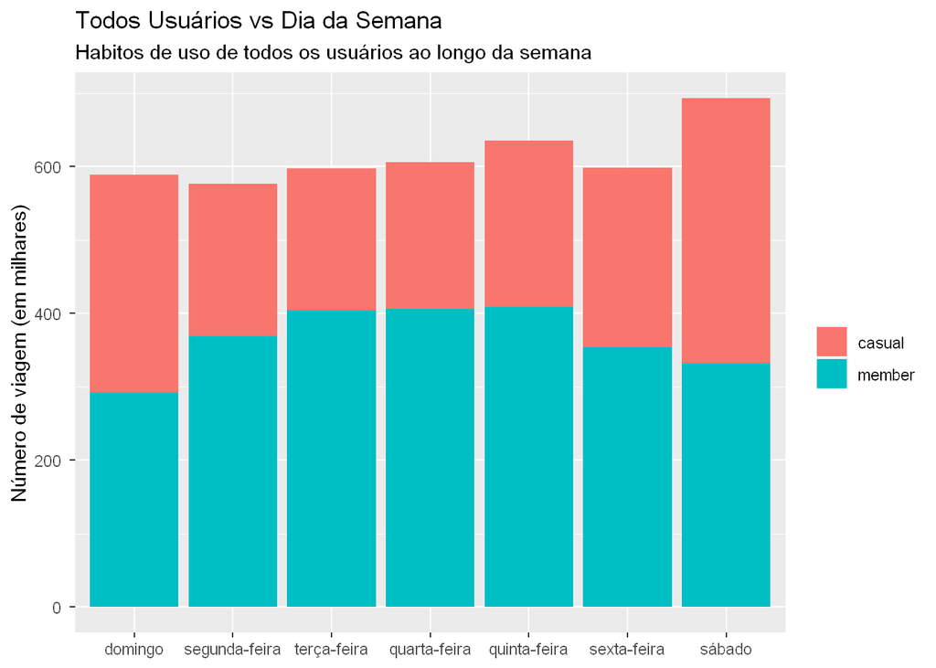

```r
    ordem = c("domingo", "segunda-feira", "terça-feira", "quarta-feira", "quinta-feira", "sexta-feira", "sábado")
    #Dias da semana mais utilizados
    ggplot(data = cyclistic_viagens_l) +
        geom_bar(mapping = aes(x = weekday, fill=member_casual)) +
        scale_x_discrete (limits = ordem) +
        scale_y_continuous(labels= unit_format(unit="", scale=1/1e03, digits = 2)) +
        labs(title="Todos Usuários vs Dia da Semana",
             subtitle="Habitos de uso de todos os usuários ao longo da semana" ,
             x=NULL,
             y="Número de viagem (em milhares)") +
        theme(legend.title = element_blank())
```

```r
    #Estações de início de viagem com maior e menor movimento
    top_station_all <- cyclistic_viagens_l %>% count(start_station_name) %>% arrange(desc(n)) %>% head(10)
    worst_station_all <- cyclistic_viagens_l %>% count(start_station_name) %>% arrange(n) %>% head(10)

    cyclistic_viagens_member <- cyclistic_viagens_l %>% filter(member_casual=="member")
    cyclistic_viagens_casual <- cyclistic_viagens_l %>% filter(member_casual=="casual")

    #adicionando uma coluna de hora e uma de período ao dataframe de membros
    cyclistic_viagens_member$hora_i <- format(as.POSIXct(cyclistic_viagens_member$started_at), format= "%H:%M:%S")
    cyclistic_viagens_member <- cyclistic_viagens_member %>%
                                  mutate(periodo = case_when(
                                    hora_i >= "06:00:00" & hora_i < "11:59:59" ~"manha",
                                    hora_i >= "12:00:00" & hora_i < "17:59:59" ~"tarde",
                                    hora_i >= "18:00:00" & hora_i < "23:59:59" ~"noite",
                                    TRUE ~"madrugada")
                                  )
    ajuste_y <- c(0, 1100000)
    ajuste_y2 <- c(0, 1750000)
    quebras <- c(0, 300000, 600000, 900000)

    #Estatisticas básicas sobre membros
    mean(cyclistic_viagens_member$duration)
```

```
## Time difference of 12.67659 mins
```